# 都道府県別データを用いた人口の可視化

[岩田真一郎](https://shinichiro-iwata.github.io/)（[神奈川大学経済学部](https://www.econ.kanagawa-u.ac.jp/)）

2022-06-01

# 目的

[`NipponMap`](https://cran.r-project.org/web/packages/NipponMap/index.html)を活用して都道府県別データを可視化．今回は人口を表現する．

ライブラリ：`sf`，`tidyverse`，`Nipponmap`

- `NipponMap`をインストールしていないない場合は`#install.packages("NipponMap")`の`#`を削除し，インストール．
  - インストールは一度だけでよいため，その後このコードは削除可能．

```r
#install.packages("NipponMap")

library(sf)
library(tidyverse)
library(NipponMap)
```

# データの読込と日本地図の可視化

**シェープファイル**

`NipponMap`がインストールできれば，シェープファイル（`shapes`）がユーザライブラリにある．[^1]このファイルを現在作業しているディレクトリに移す．

- R > win-library > x.y （Rのバーション） > `NipponMap`
- 「shapes」と示されるフォルダがあるので，これをコピーし， 現在作業しているディレクトリにペーストする．
- `Nippon_map`と名付け，`read_sf()`でデータを読込．
  - シェープファイルを現在のディレクトリに移すのが面倒だと思う場合は，`Nippon_map<-`以降のコマンドを`read_sf(system.file("shapes/jpn.shp"), package="NipponMap")`にしても可能．この場合，移す作業は必要ない．
  - `crs="WGS84"`は削除しても目的は達成可能．`crs`（Coordinate ReferenceSystem，座標参照系）を1984年に定められた世界測地系(World Geodetic System)に投影を意味．

```r
Nippon_map<-read_sf("shapes/jpn.shp",
                     crs="WGS84")
```

**日本地図の可視化**

- `ggplot()`を用いて都道府県の境界が示された日本地図を可視化．
- `ggplot()`を用いた可視化に関しては，括弧内の示し方が何通りがあるか，このチュートリアルではできるだけ次のように統一する．
  - `ggplot()`：括弧内記入なし．
  - `geom_sf()`：シェープファイルに含まれる図形（地物）・属性情報を可視化する関数．`data=Nippon_map`をデータとして利用するように指示．

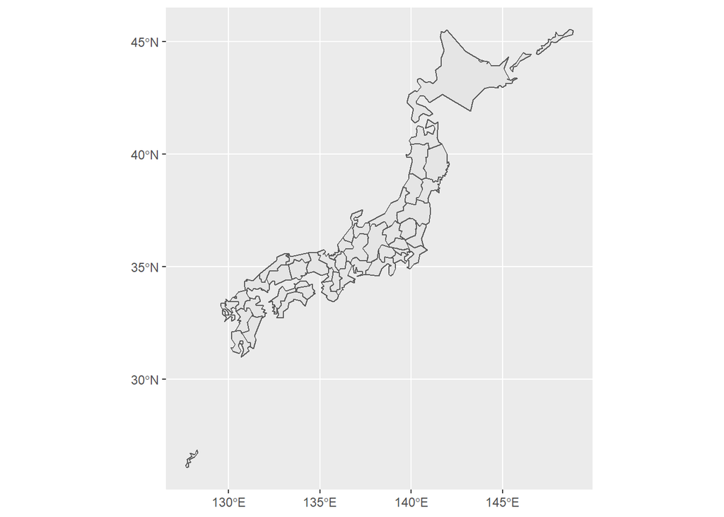

```r
ggplot()+
  geom_sf(data=Nippon_map)
```